# 02_primeros_pasos_hdfs_executed

### Ejercicios prácticos: Operaciones básicas en HDFS

Todos los ejercicios se deben ejecutar como usuario `root` en el contenedor del NameNode. Para cambiar al usuario `root`, ejecuta:

```
# No need to switch user, running as root
```

#### **Ejercicio 1: Exploración de directorios**

Explora la estructura de directorios en HDFS usando los siguientes comandos:

```
# Listar el contenido del directorio home de root
hdfs dfs -ls

# Listar el contenido del directorio raíz /
hdfs dfs -ls /

# Listar el contenido del directorio /tmp
hdfs dfs -ls /tmp

# Listar directorios con información detallada (tamaño, permisos, etc.)
hdfs dfs -ls -h /user
```

#### **Ejercicio 2: Crear directorios**

Crea una estructura de directorios en HDFS bajo tu directorio home:

```
# Crear un directorio llamado "datos"
hdfs dfs -mkdir datos

# Crear un subdirectorio "datos/entrada" (requiere que "datos" exista)
hdfs dfs -mkdir datos/entrada

# Crear múltiples directorios de una vez con -p (crea padres si no existen)
hdfs dfs -mkdir -p datos/procesados/resultados

# Verificar que se han creado correctamente
hdfs dfs -ls -R datos
```

#### **Ejercicio 3: Crear archivos de prueba**

Crea algunos archivos de texto para practicar:

```
# Crear un archivo local de prueba
echo "Este es el contenido del archivo 1" > /tmp/archivo1.txt
echo "Contenido del archivo número 2" > /tmp/archivo2.txt

# Copiar archivos locales a HDFS
hdfs dfs -put /tmp/archivo1.txt datos/entrada/
hdfs dfs -put /tmp/archivo2.txt datos/entrada/

# Crear un archivo directamente en HDFS usando echo (a través de una tubería)
echo "Archivo creado directamente en HDFS" | hdfs dfs -put - datos/archivo_directo.txt

# Verificar los archivos creados
hdfs dfs -ls datos/entrada/
hdfs dfs -ls datos/
```

#### **Ejercicio 4: Ver el contenido de archivos**

Lee el contenido de los archivos que has creado:

```
# Ver el contenido de un archivo (similar a cat en el sistema local)
hdfs dfs -cat datos/entrada/archivo1.txt

# Ver el contenido de múltiples archivos
hdfs dfs -cat datos/entrada/archivo1.txt datos/entrada/archivo2.txt

# Ver el contenido con más detalle (muestra también el número de líneas)
hdfs dfs -cat datos/archivo_directo.txt | wc -l

# Ver solo las primeras líneas de un archivo
hdfs dfs -cat datos/entrada/archivo1.txt | head -n 5
```

#### **Ejercicio 5: Copiar y mover archivos**

Practica copiando y moviendo archivos dentro de HDFS:

```
# Copiar un archivo a otra ubicación
hdfs dfs -cp datos/entrada/archivo1.txt datos/copia_archivo1.txt

# Mover un archivo a otro directorio
hdfs dfs -mv datos/copia_archivo1.txt datos/procesados/

# Verificar que el archivo se ha movido
hdfs dfs -ls datos/procesados/
hdfs dfs -ls datos/entrada/
```

#### **Ejercicio 6: Información sobre archivos y directorios**

Obtén información detallada sobre archivos y directorios:

```
# Ver el tamaño total de un directorio
hdfs dfs -du -h datos/

# Ver el tamaño de cada archivo dentro de un directorio
hdfs dfs -du -h -v datos/entrada/

# Contar el número de archivos en un directorio
hdfs dfs -ls -R datos/ | grep "^-" | wc -l

# Ver información detallada de un archivo específico
hdfs dfs -ls -l datos/entrada/archivo1.txt

# Ver el espacio total usado y disponible en HDFS
hdfs dfsadmin -report | grep "Configured Capacity\|DFS Used\|DFS Remaining"
```

#### **Ejercicio 7: Cambiar permisos y propietarios**

Trabaja con permisos de archivos en HDFS:

```
# Cambiar permisos de un archivo (modo octal)
hdfs dfs -chmod 644 datos/entrada/archivo1.txt

# Ver los permisos actuales
hdfs dfs -ls -l datos/entrada/

# Cambiar permisos de un directorio y su contenido recursivamente
hdfs dfs -chmod -R 755 datos/

# Cambiar el propietario de un archivo (requiere permisos de admin)
# hdfs dfs -chown root:root datos/entrada/archivo1.txt
```

#### **Ejercicio 8: Comparar archivos locales y en HDFS**

Compara un archivo local con uno en HDFS:

```
# Ver el contenido del archivo local
cat /tmp/archivo1.txt

# Ver el contenido del archivo en HDFS
hdfs dfs -cat datos/entrada/archivo1.txt

# Descargar un archivo de HDFS al sistema local
hdfs dfs -get datos/entrada/archivo1.txt /tmp/descargado.txt

# Comparar los dos archivos
diff /tmp/archivo1.txt /tmp/descargado.txt
```

#### **Ejercicio 9: Eliminar archivos y directorios**

Practica eliminando archivos y directorios:

```
# Eliminar un archivo específico
hdfs dfs -rm datos/archivo_directo.txt

# Verificar que se ha eliminado
hdfs dfs -ls datos/

# Eliminar un directorio vacío
hdfs dfs -rmdir datos/procesados/resultados

# Eliminar un directorio con contenido (requiere -r para recursivo)
hdfs dfs -rm -r datos/procesados/

# Eliminar múltiples archivos
hdfs dfs -rm datos/entrada/archivo1.txt datos/entrada/archivo2.txt

# Verificar el estado final
hdfs dfs -ls -R datos/
```

#### **Ejercicio 10: Limpieza final**

Limpia toda la estructura de directorios y archivos que creaste:

```
# Eliminar el directorio raíz con todo su contenido
hdfs dfs -rm -r datos/

# Verificar que se ha eliminado
hdfs dfs -ls

# Confirmación: el directorio home debe estar vacío (o solo contener "libros" si lo cargaste)
```

```python
# Listar el contenido del directorio home de root
!hdfs dfs -ls

# Listar el contenido del directorio raíz /
!hdfs dfs -ls /

# Listar el contenido del directorio /tmp
!hdfs dfs -ls /tmp

# Listar directorios con información detallada (tamaño, permisos, etc.)
!hdfs dfs -ls -h /user
```

```
Found 1 items
drwxr-xr-x   - root supergroup          0 2026-03-11 09:42 libros
Found 2 items
drwxr-xr-x   - jovyan supergroup          0 2026-02-26 18:49 /data
drwxr-xr-x   - jovyan supergroup          0 2026-03-11 09:38 /user
ls: `/tmp': No such file or directory
Found 4 items
drwxr-xr-x   - jovyan supergroup          0 2026-02-26 19:15 /user/alumnos
drwxr-xr-x   - root   supergroup          0 2026-03-11 09:17 /user/hadoop
drwxr-xr-x   - jovyan supergroup          0 2026-03-11 09:30 /user/jovyan
drwxr-xr-x   - root   supergroup          0 2026-03-11 09:43 /user/root
```

```python
# Crear un directorio llamado "datos"
!hdfs dfs -mkdir datos

# Crear un subdirectorio "datos/entrada" (requiere que "datos" exista)
!hdfs dfs -mkdir datos/entrada

# Crear múltiples directorios de una vez con -p (crea padres si no existen)
!hdfs dfs -mkdir -p datos/procesados/resultados

# Verificar que se han creado correctamente
!hdfs dfs -ls -R datos
```

```
drwxr-xr-x   - root supergroup          0 2026-03-11 10:19 datos/entrada
drwxr-xr-x   - root supergroup          0 2026-03-11 10:19 datos/procesados
drwxr-xr-x   - root supergroup          0 2026-03-11 10:19 datos/procesados/resultados
```

```python
# Usar en terminal - Puede dar porblemas o bloquearse en Jupyter
# Crear un archivo local de prueba
# !echo "Este es el contenido del archivo 1" > /tmp/archivo1.txt
!echo "Contenido del archivo número 2" > /tmp/archivo2.txt

# Copiar archivos locales a HDFS
# !hdfs dfs -put /tmp/archivo1.txt datos/entrada/
# !hdfs dfs -put /tmp/archivo2.txt datos/entrada/

# CREAMOS DIRECTAMENTE EN HDFS LO ANTERIOR
!echo "Este es el contenido del archivo 1" | hdfs dfs -put - datos/entrada/archivo1.txt
!echo "Contenido del archivo numero 2" | hdfs dfs -put - datos/entrada/archivo2.txt

# Crear un archivo directamente en HDFS usando echo (a través de una tubería)
!echo "Archivo creado directamente en HDFS" | hdfs dfs -put - datos/archivo_directo.txt

# Verificar los archivos creados
!hdfs dfs -ls datos/entrada/
!hdfs dfs -ls datos/
```

```
Found 2 items
-rw-r--r--   2 root supergroup         35 2026-03-11 10:19 datos/entrada/archivo1.txt
-rw-r--r--   2 root supergroup         31 2026-03-11 10:20 datos/entrada/archivo2.txt
Found 3 items
-rw-r--r--   2 root supergroup         36 2026-03-11 10:20 datos/archivo_directo.txt
drwxr-xr-x   - root supergroup          0 2026-03-11 10:20 datos/entrada
drwxr-xr-x   - root supergroup          0 2026-03-11 10:19 datos/procesados
```

```python
# COMPROBACION DE CODIFICACIÓN
# import unicodedata as ud

# s = "Contenido del archivo número 2"  # <- pega aquí la versión que te falla
# [(c, hex(ord(c)), ud.name(c, "?")) for c in s]
```

```python
# COMPROBACION DE CODIFICACIÓN
# !locale
# !python -c "import locale, sys; print('preferred:', locale.getpreferredencoding(False)); print('fs:', sys.getfilesystemencoding())"
# !echo $LANG ; echo $LC_ALL
```

```python
# Ver el contenido de un archivo (similar a cat en el sistema local)
!hdfs dfs -cat datos/entrada/archivo1.txt

# Ver el contenido de múltiples archivos
!hdfs dfs -cat datos/entrada/archivo1.txt datos/entrada/archivo2.txt

# Ver el contenido con más detalle (muestra también el número de líneas)
!hdfs dfs -cat datos/archivo_directo.txt | wc -l

# Ver solo las primeras líneas de un archivo
!hdfs dfs -cat datos/entrada/archivo1.txt | head -n 5
```

```
Este es el contenido del archivo 1
Este es el contenido del archivo 1
Contenido del archivo numero 2
1
Este es el contenido del archivo 1
```

```python
# Copiar un archivo a otra ubicación
!hdfs dfs -cp datos/entrada/archivo1.txt datos/copia_archivo1.txt

# Mover un archivo a otro directorio
!hdfs dfs -mv datos/copia_archivo1.txt datos/procesados/

# Verificar que el archivo se ha movido
!hdfs dfs -ls datos/procesados/
!hdfs dfs -ls datos/entrada/
```

```
Found 2 items
-rw-r--r--   2 root supergroup         35 2026-03-11 10:20 datos/procesados/copia_archivo1.txt
drwxr-xr-x   - root supergroup          0 2026-03-11 10:19 datos/procesados/resultados
Found 2 items
-rw-r--r--   2 root supergroup         35 2026-03-11 10:19 datos/entrada/archivo1.txt
-rw-r--r--   2 root supergroup         31 2026-03-11 10:20 datos/entrada/archivo2.txt
```

```python
# Ver el tamaño total de un directorio
!hdfs dfs -du -h datos/

# Ver el tamaño de cada archivo dentro de un directorio
!hdfs dfs -du -h -v datos/entrada/

# Contar el número de archivos en un directorio
!hdfs dfs -ls -R datos/ | grep "^-" | wc -l

# Ver información detallada de un archivo específico
!hdfs dfs -ls -l datos/entrada/archivo1.txt

# Ver el espacio total usado y disponible en HDFS
!hdfs dfsadmin -report | grep "Configured Capacity\|DFS Used\|DFS Remaining"
```

[output not shown]

[output cut: 27 more lines]

```
DFS Remaining: 1906634366976 (1.73 TB)
DFS Used: 33010307434 (30.74 GB)
DFS Used%: 1.70%
Configured Capacity: 1081101176832 (1006.85 GB)
DFS Used: 16505180341 (15.37 GB)
Non DFS Used: 56286457675 (52.42 GB)
DFS Remaining: 953317183488 (887.85 GB)
DFS Used%: 1.53%
DFS Remaining%: 88.18%
Configured Capacity: 1081101176832 (1006.85 GB)
DFS Used: 16505127093 (15.37 GB)
Non DFS Used: 56286510923 (52.42 GB)
DFS Remaining: 953317183488 (887.85 GB)
DFS Used%: 1.53%
DFS Remaining%: 88.18%
```

```python
# Cambiar permisos de un archivo (modo octal)
!hdfs dfs -chmod 644 datos/entrada/archivo1.txt

# Ver los permisos actuales
!hdfs dfs -ls datos/entrada/

# Cambiar permisos de un directorio y su contenido recursivamente
!hdfs dfs -chmod -R 755 datos/

# Cambiar el propietario de un archivo (requiere permisos de admin)
# hdfs dfs -chown root:root datos/entrada/archivo1.txt
```

```
Found 2 items
-rw-r--r--   2 root supergroup         35 2026-03-11 10:19 datos/entrada/archivo1.txt
-rw-r--r--   2 root supergroup         31 2026-03-11 10:20 datos/entrada/archivo2.txt
```

```python
# Ver el contenido del archivo local
!cat /tmp/archivo1.txt

# Ver el contenido del archivo en HDFS
!hdfs dfs -cat datos/entrada/archivo1.txt

# Descargar un archivo de HDFS al sistema local
!hdfs dfs -get datos/entrada/archivo1.txt /tmp/descargado.txt

# Comparar los dos archivos
!diff /tmp/archivo1.txt /tmp/descargado.txt
```

```
cat: /tmp/archivo1.txt: No such file or directory
Este es el contenido del archivo 1
get: `/tmp/descargado.txt': File exists
diff: /tmp/archivo1.txt: No such file or directory
```

```python
# Eliminar un archivo específico
!hdfs dfs -rm datos/archivo_directo.txt

# Verificar que se ha eliminado
!hdfs dfs -ls datos/

# Eliminar un directorio vacío
!hdfs dfs -rmdir datos/procesados/resultados

# Eliminar un directorio con contenido (requiere -r para recursivo)
!hdfs dfs -rm -r datos/procesados/

# Eliminar múltiples archivos
!hdfs dfs -rm datos/entrada/archivo1.txt datos/entrada/archivo2.txt

# Verificar el estado final
!hdfs dfs -ls -R datos/
```

```
Deleted datos/archivo_directo.txt
Found 2 items
drwxr-xr-x   - root supergroup          0 2026-03-11 10:20 datos/entrada
drwxr-xr-x   - root supergroup          0 2026-03-11 10:20 datos/procesados
Deleted datos/procesados
Deleted datos/entrada/archivo1.txt
Deleted datos/entrada/archivo2.txt
drwxr-xr-x   - root supergroup          0 2026-03-11 10:22 datos/entrada
```

```python
# Eliminar el directorio raíz con todo su contenido
!hdfs dfs -rm -r datos/

# Verificar que se ha eliminado
!hdfs dfs -ls

# Confirmación: el directorio home debe estar vacío (o solo contener "libros" si lo cargaste)
```

```
Deleted datos
Found 1 items
drwxr-xr-x   - root supergroup          0 2026-03-11 09:42 libros
```

### Prueba de acceso a HDFS y carga de datos

```
hdfs dfs -ls
```

3. Descarga de https://github.com/dsevilla/bd2-data/releases/download/libros-tar-gz/libros.tar.gz y descomprime los ficheros de ejemplo usando:

```
wget https://github.com/dsevilla/bd2-data/releases/download/libros-tar-gz/libros.tar.gz -qO - \
  | tar -xzvf - -C /tmp
```

4. Siguiendo en el NameNode como usuario `root`, copia los datos a HDFS:

```
cd /tmp
hdfs dfs -put libros .
hdfs dfs -ls libros
```

Una vez copiados borra el directorio libros del disco local (`rm -rf /tmp/libros*`).

5. Mira en el interfaz web del HDFS dónde se encuentran los bloques correspondientes al fichero **`random_words.txt.bz2`**. Comprueba que cada bloque tiene 2 réplicas.
   - Abre el navegador y conéctate al interfaz web del NameNode.
   - Ve al menu "Utilities" -> "Browse the filesystem".

```python
!hdfs dfs -ls
```

```
Found 1 items
drwxr-xr-x   - root supergroup          0 2026-03-11 09:42 libros
```

```python
!wget https://github.com/dsevilla/bd2-data/releases/download/libros-tar-gz/libros.tar.gz -qO - \
!  | tar -xzvf - -C /tmp
```

```
libros/
libros/pg17013.txt.gz
libros/pg16625.txt.gz
libros/pg25807.txt.gz
libros/pg32315.txt.gz
libros/random_words.txt.bz2
libros/pg1619.txt.gz
libros/pg7109.txt.gz
libros/pg2000.txt.gz
libros/pg14329.txt.gz
libros/pg24536.txt.gz
libros/pg25640.txt.gz
libros/pg8870.txt.gz
libros/pg18005.txt.gz
libros/pg5201.txt.gz
libros/pg9980.txt.gz
libros/pg17073.txt.gz
```

```python
%cd /tmp
!hdfs dfs -put libros .
!hdfs dfs -ls libros
```

```
/tmp
put: `libros/pg2000.txt.gz': File exists
put: `libros/pg1619.txt.gz': File exists
put: `libros/pg14329.txt.gz': File exists
put: `libros/pg9980.txt.gz': File exists
put: `libros/pg7109.txt.gz': File exists
put: `libros/random_words.txt.bz2': File exists
put: `libros/pg17013.txt.gz': File exists
put: `libros/pg8870.txt.gz': File exists
put: `libros/pg25640.txt.gz': File exists
put: `libros/pg16625.txt.gz': File exists
put: `libros/pg18005.txt.gz': File exists
put: `libros/pg32315.txt.gz': File exists
put: `libros/pg5201.txt.gz': File exists
put: `libros/pg24536.txt.gz': File exists
put: `libros/pg25807.txt.gz': File exists
put: `libros/pg17073.txt.gz': File exists
Found 16 items
-rw-r--r--   2 root supergroup     441804 2026-03-11 09:41 libros/pg14329.txt.gz
-rw-r--r--   2 root supergroup     264123 2026-03-11 09:41 libros/pg1619.txt.gz
-rw-r--r--   2 root supergroup     455129 2026-03-11 09:42 libros/pg16625.txt.gz
-rw-r--r--   2 root supergroup     939502 2026-03-11 09:42 libros/pg17013.txt.gz
-rw-r--r--   2 root supergroup     737367 2026-03-11 09:42 libros/pg17073.txt.gz
-rw-r--r--   2 root supergroup     219304 2026-03-11 09:42 libros/pg18005.txt.gz
-rw-r--r--   2 root supergroup     813698 2026-03-11 09:41 libros/pg2000.txt.gz
-rw-r--r--   2 root supergroup     328494 2026-03-11 09:42 libros/pg24536.txt.gz
-rw-r--r--   2 root supergroup     504188 2026-03-11 09:42 libros/pg25640.txt.gz
-rw-r--r--   2 root supergroup      38194 2026-03-11 09:42 libros/pg25807.txt.gz
-rw-r--r--   2 root supergroup     103986 2026-03-11 09:42 libros/pg32315.txt.gz
-rw-r--r--   2 root supergroup     125693 2026-03-11 09:42 libros/pg5201.txt.gz
-rw-r--r--   2 root supergroup      82099 2026-03-11 09:41 libros/pg7109.txt.gz
-rw-r--r--   2 root supergroup      99685 2026-03-11 09:42 libros/pg8870.txt.gz
-rw-r--r--   2 root supergroup      85187 2026-03-11 09:41 libros/pg9980.txt.gz
-rw-r--r--   2 root supergroup  330326458 2026-03-11 09:42 libros/random_words.txt.bz2
```

### Acceso a HDFS desde python con `pyarrow`

PyArrow proporciona una interfaz Python para interactuar con HDFS a través de su módulo `pyarrow.fs.HadoopFileSystem`. Esto nos permite realizar operaciones sobre HDFS directamente desde Python sin necesidad de usar comandos de shell.

#### Preparación del entorno

**Como usuario `root` en el contenedor namenode**, ejecuta los siguientes pasos:

1. **Crear un entorno virtual Python:**

```
# Conectarse al contenedor namenode
docker exec -it namenode /bin/bash

# Cambiar al usuario root
# No need to switch user, running as root

# Crear el entorno virtual
python3 -m venv ~/.venv

# Activar el entorno virtual
source ~/.venv/bin/activate
```

2. **Instalar PyArrow:**

```
# Con el entorno virtual activado
pip install pyarrow
```

3. **Configurar las variables de entorno para Hadoop:**

```
export CLASSPATH="$(hadoop classpath --glob):$CLASSPATH"
```

4. **Verificar la instalación:**

```
python3 -c "import pyarrow as pa; print(f'PyArrow version: {pa.__version__}')"
```

```python
# Conectarse al contenedor namenode
!docker exec -it namenode /bin/bash

# Cambiar al usuario root
# No need to switch user, running as root

# Crear el entorno virtual
!python3 -m venv ~/.venv

# Activar el entorno virtual
# source ~/.venv/bin/activate # 'source' no funciona en celdas, usar variables de entorno Python
```

```
/bin/bash: line 1: docker: command not found
```

```python
# Con el entorno virtual activado
!pip install pyarrow
```

[output not shown]

```python
!export CLASSPATH="$(hadoop classpath --glob):$CLASSPATH"
```

```python
!python3 -c "import pyarrow as pa; print(f'PyArrow version: {pa.__version__}')"
```

```
PyArrow version: 23.0.1
```

#### Ejemplos de uso del API de PyArrow FileSystem

A continuación se muestran ejemplos equivalentes a los comandos `hdfs dfs` vistos anteriormente, pero usando Python y PyArrow:

```python
%pip install -q --upgrade pyarrow
```

[output not shown]

```python
# Execute hadoop classpath --glob and set CLASSPATH environment variable
import os
import subprocess

classpath = subprocess.check_output(["hadoop", "classpath", "--glob"]).decode("utf-8").strip()
os.environ["CLASSPATH"] = classpath
```

##### **Ejemplo 1: Conectar a HDFS y listar directorios**

```python
import pyarrow as pa
from pyarrow import fs
from pyarrow.fs import FileInfo, FileSystem

# Conectar a HDFS (namenode en puerto 9000)
hdfs: FileSystem = fs.HadoopFileSystem(host="namenode", port=9000, user="jovyan")


def print_file_list_info(file_info_list: list[FileInfo]):
    for file_info in file_info_list:
        file_type: str | None = file_info.type.name if file_info.type else "UNKNOWN"
        file_size: int = file_info.size if file_info.size is not None else 0
        print(f"{file_type:10} {file_size:>10} {file_info.path}")


# Listar contenido del directorio home del usuario
print("=== Contenido del directorio home ===")
file_info_list: list[FileInfo] = hdfs.get_file_info(fs.FileSelector("/user/jovyan"))
print_file_list_info(file_info_list)

# Listar el directorio raíz
print("\n=== Contenido del directorio raíz / ===")
root_info: list[FileInfo] = hdfs.get_file_info(fs.FileSelector("/"))
print_file_list_info(root_info)
```

```
=== Contenido del directorio home ===

=== Contenido del directorio raíz / ===
Directory           0 /data
Directory           0 /user
```

##### **Ejemplo 2: Crear directorios**

```python
# Crear un directorio simple
hdfs.create_dir("/user/root/datos_python")
print("Directorio 'datos_python' creado")

# Crear estructura de directorios (equivalente a mkdir -p)
hdfs.create_dir("/user/root/datos_python/entrada")
hdfs.create_dir("/user/root/datos_python/procesados/resultados")
print("Estructura de directorios creada")

# Verificar creación
file_list: list[FileInfo] = hdfs.get_file_info(
    fs.FileSelector("/user/root/datos_python", recursive=True)
)
print("=== Estructura creada ===")
print_file_list_info(file_list)
```

```
Directorio 'datos_python' creado
Estructura de directorios creada
=== Estructura creada ===
Directory           0 /user/root/datos_python/entrada
Directory           0 /user/root/datos_python/procesados
Directory           0 /user/root/datos_python/procesados/resultados
```

##### **Ejemplo 3: Escribir archivos en HDFS**

```python
# Escribir un archivo de texto directamente en HDFS
with hdfs.open_output_stream("/user/root/datos_python/entrada/archivo1.txt") as f:
    f.write(b"Este es el contenido del archivo 1 desde Python\n")
    f.write("Segunda línea del archivo\n".encode())

print("Archivo archivo1.txt creado")

# Escribir otro archivo
contenido = "Contenido del archivo número 2 desde PyArrow"
with hdfs.open_output_stream("/user/root/datos_python/entrada/archivo2.txt") as f:
    f.write(contenido.encode("utf-8"))

print("Archivo archivo2.txt creado")

# Copiar un archivo local a HDFS
import os

# Crear archivo local temporal
local_file = "/tmp/archivo_local.txt"
with open(local_file, "w") as f:
    f.write("Contenido desde archivo local\n")

# Copiar a HDFS usando copy_file
with open(local_file, "rb") as local_f:
    with hdfs.open_output_stream("/user/root/datos_python/desde_local.txt") as hdfs_f:
        hdfs_f.write(local_f.read())

print("Archivo copiado desde local a HDFS")

# Limpiar archivo local
os.remove(local_file)
```

```
Archivo archivo1.txt creado
Archivo archivo2.txt creado
Archivo copiado desde local a HDFS
```

##### **Ejemplo 4: Leer archivos de HDFS**

```python
# Leer contenido de un archivo (equivalente a hdfs dfs -cat)
with hdfs.open_input_stream("/user/root/datos_python/entrada/archivo1.txt") as f:
    contenido: bytes = f.read()
    print("=== Contenido de archivo1.txt ===")
    print(contenido.decode("utf-8"))

# Leer con readall (más eficiente para archivos completos)
contenido2: bytes = hdfs.open_input_stream(
    "/user/root/datos_python/entrada/archivo2.txt"
).readall()
print("\n=== Contenido de archivo2.txt ===")
print(contenido2.decode("utf-8"))
```

```
=== Contenido de archivo1.txt ===
Este es el contenido del archivo 1 desde Python
Segunda línea del archivo


=== Contenido de archivo2.txt ===
Contenido del archivo número 2 desde PyArrow
```

##### **Ejemplo 5: Copiar y mover archivos dentro de HDFS**

```python
# Copiar un archivo (PyArrow no tiene copy directo, hay que leer y escribir)


def copy_file_hdfs(hdfs_fs, src, dst):
    """Copia un archivo en HDFS de src a dst"""
    with hdfs_fs.open_input_stream(src) as f_in:
        with hdfs_fs.open_output_stream(dst) as f_out:
            f_out.write(f_in.read())


# Copiar archivo
copy_file_hdfs(
    hdfs,
    "/user/root/datos_python/entrada/archivo1.txt",
    "/user/root/datos_python/copia_archivo1.txt",
)
print("Archivo copiado")

# Mover archivo (equivalente a hdfs dfs -mv)
hdfs.move(
    "/user/root/datos_python/copia_archivo1.txt",
    "/user/root/datos_python/procesados/archivo_movido.txt",
)
print("Archivo movido")

# Verificar
print_file_list_info(hdfs.get_file_info(fs.FileSelector("/user/root/datos_python/procesados")))
```

```
Archivo copiado
Archivo movido
File               75 /user/root/datos_python/procesados/archivo_movido.txt
Directory           0 /user/root/datos_python/procesados/resultados
```

##### **Ejemplo 6: Obtener información de archivos**

```python
from pyarrow.fs import FileInfo

# Información detallada de un archivo específico
file_info: FileInfo = hdfs.get_file_info("/user/root/datos_python/entrada/archivo1.txt")
print("=== Información de archivo ===")
print(f"Ruta: {file_info.path}")
print(f"Tipo: {file_info.type.name}")
print(f"Tamaño: {file_info.size} bytes")
print(f"Tiempo modificación: {file_info.mtime}")

# Tamaño de un directorio (recursivo)
dir_selector = fs.FileSelector("/user/root/datos_python", recursive=True)
total_size = 0
file_count = 0

for info in hdfs.get_file_info(dir_selector):
    if info.type == fs.FileType.File:
        total_size += info.size
        file_count += 1
        print(f"{info.size:>10} bytes  {info.path}")

print(f"\nTotal: {file_count} archivos, {total_size} bytes")
```

```
=== Información de archivo ===
Ruta: /user/root/datos_python/entrada/archivo1.txt
Tipo: File
Tamaño: 75 bytes
Tiempo modificación: 2026-03-11 10:25:42+00:00
        30 bytes  /user/root/datos_python/desde_local.txt
        75 bytes  /user/root/datos_python/entrada/archivo1.txt
        45 bytes  /user/root/datos_python/entrada/archivo2.txt
        75 bytes  /user/root/datos_python/procesados/archivo_movido.txt

Total: 4 archivos, 225 bytes
```

##### **Ejemplo 7: Eliminar archivos y directorios**

```python
# Eliminar un archivo específico
hdfs.delete_file("/user/root/datos_python/desde_local.txt")
print("Archivo eliminado")

# Eliminar directorio con contenido (equivalente a hdfs dfs -rm -r)
hdfs.delete_dir("/user/root/datos_python/procesados")
print("Directorio 'procesados' eliminado recursivamente")

# Verificar eliminación
remaining: list[FileInfo] = hdfs.get_file_info(
    fs.FileSelector("/user/root/datos_python", recursive=True)
)
print("\n=== Archivos restantes ===")
for info in remaining:
    print(f"{info.type.name:10} {info.path}")
```

```
Archivo eliminado
Directorio 'procesados' eliminado recursivamente

=== Archivos restantes ===
Directory  /user/root/datos_python/entrada
File       /user/root/datos_python/entrada/archivo1.txt
File       /user/root/datos_python/entrada/archivo2.txt
```

##### **Ejemplo 8: Trabajar con PyArrow Tables y Parquet**

PyArrow es especialmente útil para trabajar con datos en formato Parquet directamente en HDFS:

```python
import pandas as pd
import pyarrow.parquet as pq

# Crear un DataFrame de ejemplo
df = pd.DataFrame(
    {
        "id": range(1, 101),
        "nombre": [f"Producto_{i}" for i in range(1, 101)],
        "precio": [10.5 + i * 0.5 for i in range(100)],
        "categoria": ["A", "B", "C", "D"] * 25,
    }
)

# Convertir a tabla de PyArrow
table: pa.Table = pa.Table.from_pandas(df)

# Escribir como Parquet en HDFS
pq.write_table(table, "/user/root/datos_python/productos.parquet", filesystem=hdfs)
print("Archivo Parquet escrito en HDFS")

# Leer el archivo Parquet desde HDFS
tabla_leida: pa.Table = pq.read_table("/user/root/datos_python/productos.parquet", filesystem=hdfs)
print("\n=== Tabla leída desde HDFS ===")
print(f"Filas: {tabla_leida.num_rows}, Columnas: {tabla_leida.num_columns}")
print(tabla_leida.schema)

# Convertir de vuelta a pandas
df_leido: pd.DataFrame = tabla_leida.to_pandas()
print("\nPrimeras filas:")
print(df_leido.head())
```

```
Archivo Parquet escrito en HDFS

=== Tabla leída desde HDFS ===
Filas: 100, Columnas: 4
id: int64
nombre: string
precio: double
categoria: string
-- schema metadata --
pandas: '{"index_columns": [{"kind": "range", "name": null, "start": 0, "' + 723

Primeras filas:
   id      nombre  precio categoria
0   1  Producto_1    10.5         A
1   2  Producto_2    11.0         B
2   3  Producto_3    11.5         C
3   4  Producto_4    12.0         D
4   5  Producto_5    12.5         A
```

##### **Ejemplo 9: Limpieza final**

```python
# Eliminar todo el directorio de prueba
hdfs.delete_dir("/user/root/datos_python")
print("Directorio 'datos_python' eliminado completamente")

# Verificar que el directorio home está limpio
print("=== Contenido final del directorio home ===")
print_file_list_info(hdfs.get_file_info(fs.FileSelector("/user/root")))
```

```
Directorio 'datos_python' eliminado completamente
=== Contenido final del directorio home ===
Directory           0 /user/root/libros
```

#### Ventajas de usar PyArrow para HDFS

- **Integración nativa**: Conexión directa con HDFS sin necesidad de comandos shell
- **Formato Parquet**: Lectura/escritura eficiente de datos columnares
- **Rendimiento**: Operaciones optimizadas en C++ subyacente
- **Portabilidad**: Mismo código funciona con diferentes sistemas de archivos (HDFS, S3, local)
- **Pythonic**: API orientada a objetos más natural para desarrolladores Python

### Acceso con Visual Studio Code al clúster a través de un servidor Jupyter

El contenedor del NameNode/ResourceManager se puede ejecutar un servidor Jupyter que permite acceder al clúster Hadoop a través de una URL de conexión a un servidor Jupyter, y por lo tanto, a través de Visual Studio Code (y también de la web).

Existen varias formas de hacerlo. Por ejemplo, usando la utilidad "DevContainer" de Visual Studio Code, que permite definir un entorno de desarrollo basado en contenedores Docker. Sin embargo, lo haremos manualmente.

A continuación se explica cómo hacerlo.

Lo primero, suponemos que existe un virtual environment de Python para el usuario `root`. Si no es así, créalo y actívalo:

```
python3 -m venv ~/.venv
. ~/.venv/bin/activate
```

Si ya existe, sólo hace falta activarlo:

```
. ~/.venv/bin/activate
```

```python
!python3 -m venv ~/.venv
!. ~/.venv/bin/activate
```

```python
!. ~/.venv/bin/activate
```

Lo siguiente es instalar los paquetes necesarios:

```
pip install jupyter
```

```python
!pip install jupyter
```

[output not shown]

Una vez instalado Jupyter, lanza el servidor Jupyter con el siguiente comando (como usuario `root`):

```
jupyter notebook --ip=0.0.0.0 --no-browser --allow-root --NotebookApp.token='bigdata' --NotebookApp.password=''
```

```python
!jupyter notebook --ip=0.0.0.0 --no-browser --allow-root --NotebookApp.token='bigdata' --NotebookApp.password=''
```

[output not shown]

[output cut: 9 more lines]

[output not shown]

En Visual Studio Code, hay que seleccionar el kernel:

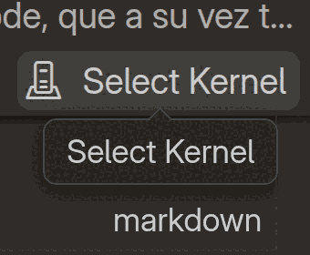

Después, "Select Another Kernel..." y en la ventana que aparece, seleccionar "Existing Jupyter Server":

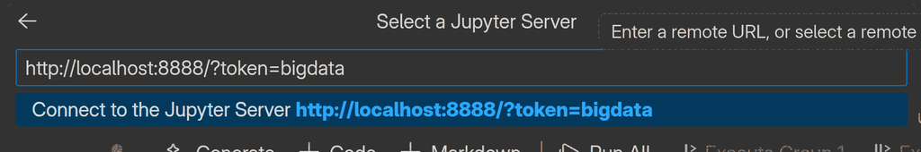

Con la URL `http://localhost:8888/?token=bigdata`.

A partir de ahí, todos los *Notebooks* locales se ejecutarán en el contenedor del NameNode, con acceso al clúster Hadoop.

http://localhost:8888/?token=bigdata